# Machine Learning Engineer Nano degree Capstone Project

One of my primary areas of focus, and in fact the reason I decided to do the Machine Learning nanodegree originally, is Image processing medical image scan . the last part for this course was Deep-Learning and CNN –this part is important part for me. I interesting of medical image on the last a few years the detection of diseases by CNN or NN became more important to make diagnoses easy and safe more time . CNN use X-ray Dataset of machine learning, computer vision and various other

in this Project i have 14 categories for all diseases of the chest using Xray images this is the first normal scan for any place make scanner also first thing the doctors orderd it when he need to check by first one dignoses

import libraries

```python
import pandas as pd
import numpy as np
import os
from glob import glob
import random
import matplotlib.pylab as plt
import cv2
import matplotlib.gridspec as gridspec
import seaborn as sns
import zlib
import itertools
import sklearn
from sklearn import model_selection
from sklearn.model_selection import train_test_split
from sklearn.model_selection import learning_curve
from sklearn.model_selection import KFold
from sklearn.model_selection import cross_val_score
from sklearn.model_selection import StratifiedKFold
from sklearn.utils import class_weight
from sklearn.metrics import confusion_matrix
import keras
from keras.models import Sequential
from keras.optimizers import SGD, RMSprop, Adam, Adagrad, Adadelta
from keras.layers import Dense, Activation, Dropout
from keras.utils.np_utils import to_categorical
from keras.models import Sequential
from keras.layers import Activation,Dense, Dropout, Flatten, Conv2D, MaxPool2D,MaxPooling2D,AveragePooling2D, BatchNormalization
from keras.optimizers import RMSprop
from keras.preprocessing.image import ImageDataGenerator
from keras.callbacks import ReduceLROnPlateau, ModelCheckpoint
from keras.models import model_from_json
from keras import backend as K
from keras.layers import Conv2D, MaxPooling2D
from keras.applications.mobilenet import MobileNet
```

read the path of the images

```python
PATH = os.path.abspath(os.path.join( 'sample','images'))

#PATH = os.path.abspath(os.path.join('sample/images'))#read the path of the images
#SOURCE_IMAGES = os.path.join(PATH,'sample', 'images')
```

Show the pathes of images

```python
images=glob(os.path.join(PATH,'*.png'))

print(images[0:5])#print first 5 images
```

```
['C:\\Users\\Gsamuel\\A-    MLND\\P7\\sample\\images\\00000013_005.png', 'C:\\Users\\Gsamuel\\A-    MLND\\P7\\sample\\images\\00000013_026.png', 'C:\\Users\\Gsamuel\\A-    MLND\\P7\\sample\\images\\00000017_001.png', 'C:\\Users\\Gsamuel\\A-    MLND\\P7\\sample\\images\\00000030_001.png', 'C:\\Users\…
```

view the csv file

```python
labels = pd.read_csv('sample_labels.csv')
labels.head(10)
```

|  | Image Index | Finding Labels | Follow-up # | Patient ID | Patient Age | Patient Gender | View Position | OriginalImageWidth | OriginalImageHeight | OriginalImagePixelSpacing_x | OriginalImagePixelSpacing_y |
| --- | --- | --- | --- | --- | --- | --- | --- | --- | --- | --- | --- |
| 0 | 00000013_005.png | Emphysema\|Infiltration\|Pleural_Thickening\|Pneu... | 5 | 13 | 060Y | M | AP | 3056 | 2544 | 0.139 | 0.139 |
| 1 | 00000013_026.png | Cardiomegaly\|Emphysema | 26 | 13 | 057Y | M | AP | 2500 | 2048 | 0.168 | 0.168 |
| 2 | 00000017_001.png | No Finding | 1 | 17 | 077Y | M | AP | 2500 | 2048 | 0.168 | 0.168 |
| 3 | 00000030_001.png | Atelectasis | 1 | 30 | 079Y | M | PA | 2992 | 2991 | 0.143 | 0.143 |
| 4 | 00000032_001.png | Cardiomegaly\|Edema\|Effusion | 1 | 32 | 055Y | F | AP | 2500 | 2048 | 0.168 | 0.168 |
| 5 | 00000040_003.png | Consolidation\|Mass | 3 | 40 | 068Y | M | PA | 2500 | 2048 | 0.168 | 0.168 |
| 6 | 00000042_002.png | No Finding | 2 | 42 | 071Y | M | AP | 3056 | 2544 | 0.139 | 0.139 |
| 7 | 00000057_001.png | No Finding | 1 | 57 | 071Y | M | AP | 3056 | 2544 | 0.139 | 0.139 |
| 8 | 00000061_002.png | Effusion | 2 | 61 | 077Y | M | PA | 2992 | 2991 | 0.143 | 0.143 |
| 9 | 00000061_019.png | No Finding | 19 | 61 | 077Y | M | AP | 3056 | 2544 | 0.139 | 0.139 |

view sample of deaseses xray image

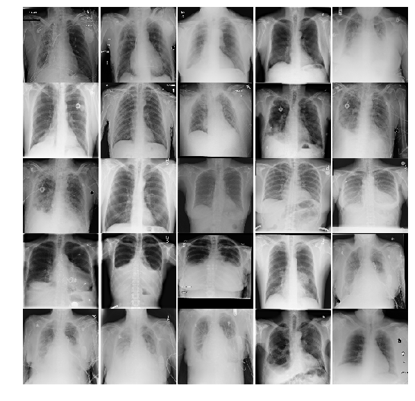

```python
multipleImages = glob('sample/images/**')
i_ = 0
plt.rcParams['figure.figsize'] = (10.0, 10.0)#command can be used to modify multiple settings in a single group at once
plt.subplots_adjust(wspace=0, hspace=0)#width+hight   5*5
for l in multipleImages[:25]:
    im = cv2.imread(l)
    im = cv2.resize(im, (128, 128)) #the size of h+w of the image
    plt.subplot(5, 5, i_+1) #.set_title(l)
    plt.imshow(cv2.cvtColor(im, cv2.COLOR_BGR2RGB)); plt.axis('off')
    i_ += 1
```

Another Way to Read and Import the Data

import libraries

```python
from sklearn.datasets import load_files
from keras.utils import np_utils
import numpy as np
from glob import glob
```

i try to separate the image and rarange it like cnn project number 6

```python
# define function to load train, test, and validation datasets
def load_dataset(path):
    data = load_files(path)
    Xray_files = np.array(data['filenames'])
    xray_targets = np_utils.to_categorical(np.array(data['target']), 133)
    return Xray_files, xray_targets

# load train, test, and validation datasets
train_files, train_targets = load_dataset('sample/images/train')
valid_files, valid_targets = load_dataset('sample/images/valid')
test_files, test_targets = load_dataset('sample/images/test')

# load list of xray names
xray_names = [item[20:-1] for item in sorted(glob("sample/images/train/*/"))]

# print statistics about the dataset
print('There are %d total Xray categories.' % len(xray_names))
print('There are %s total xray images.\n' % len(np.hstack([train_files, valid_files, test_files])))
print('There are %d training xray images.' % len(train_files))
print('There are %d validation xray images.' % len(valid_files))
print('There are %d test xray images.'% len(test_files))
```

```
There are 8 total Xray categories.
There are 2 total xray images.

There are 2 training xray images.
There are 0 validation xray images.
There are 0 test xray images.
```

Read number of the image but unforationtaly when i decompressed the image some image faild to extarct beacuse the acual number of the images 5000 images

```python
import random
random.seed(8675309)

# load filenames in shuffled human dataset
chestXRay = np.array(glob("sample/images/*"))
random.shuffle(chestXRay)

# print statistics about the dataset
print('There are %d total human images.' % len(chestXRay))
```

```
There are 4370 total human images.
```

# visualize the dataset according of partitioning of the diseases

Like this sample i token it from this paper

http://openaccess.thecvf.com/content_cvpr_2017/papers/Wang_ChestX-ray8_Hospital-Scale_Chest_CVPR_2017_paper.pdf

[figure not shown]

There are 15 classes (14 diseases, and one for "No findings") in the full dataset, but since this is drastically reduced version of the full dataset, some of the classes are sparse with the labeled as "No findings"

Hernia - 13 images Pneumonia - 62 images Fibrosis - 84 images Edema - 118 images Emphysema - 127 images Cardiomegaly - 141 images Pleural_Thickening - 176 images Consolidation - 226 images Pneumothorax - 271 images Mass - 284 images Nodule - 313 images Atelectasis - 508 images Effusion - 644 images Infiltration - 967 images No Finding - 3044 images

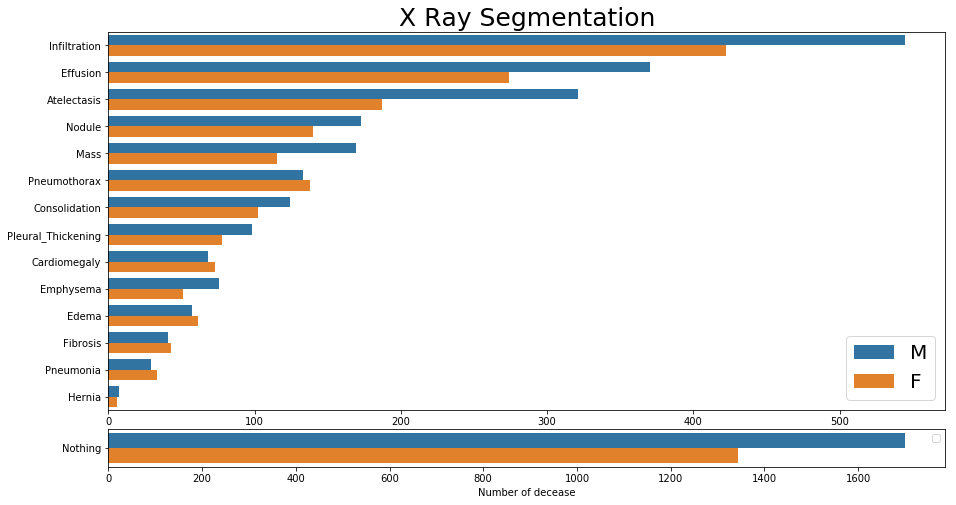

```python
#drop unused columns
labels = labels[['Image Index','Finding Labels','Follow-up #','Patient ID',
                 'Patient Age','Patient Gender']]
#create new columns for each decease
pathology_list = ['Cardiomegaly','Emphysema','Effusion','Hernia','Nodule','Pneumothorax',
                  'Atelectasis','Pleural_Thickening','Mass','Edema','Consolidation',
                  'Infiltration','Fibrosis','Pneumonia']#Make list of all diseases
for pathology in pathology_list :
    labels[pathology] = labels['Finding Labels'].apply(lambda x: 1 if pathology in x else 0)
#remove Y after age
labels['Age']=labels['Patient Age'].apply(lambda x: x[:-1]).astype(int)

plt.figure(figsize=(15,8))#size of the figure
gs = gridspec.GridSpec(8,1)
ax1 = plt.subplot(gs[:7, :])
ax2 = plt.subplot(gs[7, :])
data1 = pd.melt(labels,
             id_vars=['Patient Gender'],
             value_vars = list(pathology_list),
             var_name = 'Category',
             value_name = 'Count')
data1 = data1.loc[data1.Count>0]
g=sns.countplot(y='Category',hue='Patient Gender',data=data1, ax=ax1, order = data1['Category'].value_counts().index)
ax1.set( ylabel="",xlabel="")
ax1.legend(fontsize=20)
ax1.set_title('X Ray Segmentation',fontsize=25);

labels['Nothing']=labels['Finding Labels'].apply(lambda x: 1 if 'No Finding' in x else 0)

data2 = pd.melt(labels,
             id_vars=['Patient Gender'],
             value_vars = list(['Nothing']),
             var_name = 'Category',
             value_name = 'Count')
data2 = data2.loc[data2.Count>0]
g=sns.countplot(y='Category',hue='Patient Gender',data=data2,ax=ax2)
ax2.set( ylabel="",xlabel="Number of decease")
ax2.legend('')
plt.subplots_adjust(hspace=.5)
```

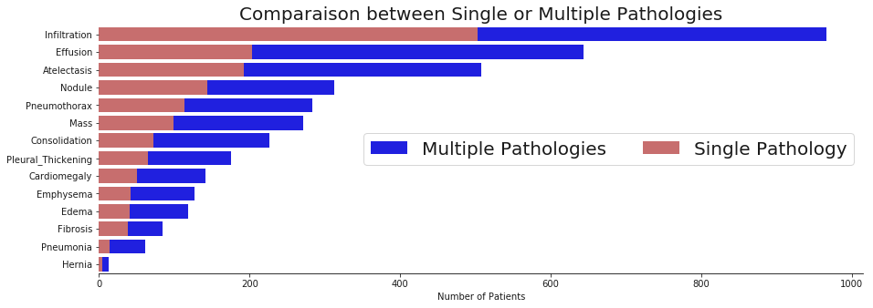

```python
df=labels
data=df.groupby('Finding Labels').count().sort_values('Patient ID',ascending=False)
df1=data[['|' in index for index in data.index]].copy()
df2=data[['|' not in index for index in data.index]]
df2=df2[['No Finding' not in index for index in df2.index]]
df2['Finding Labels']=df2.index.values
df1['Finding Labels']=df1.index.values

f, ax = plt.subplots(sharex=True,figsize=(15, 5))
g=sns.countplot(y='Category',data=data1, ax=ax, order = data1['Category'].value_counts().index,color='b',label="Multiple Pathologies")
sns.set_color_codes("muted")
g=sns.barplot(x='Patient ID',y='Finding Labels',data=df2, ax=ax, color="r",label="Single Pathology")
ax.legend(ncol=2, loc="center right", frameon=True,fontsize=20)
ax.set( ylabel="",xlabel="Number of Patients")
ax.set_title("Comparaison between Single or Multiple Pathologies",fontsize=20)
sns.despine(left=True)
```

Convert annotated .png images into labeled numpy arrays. Discard all images with more than one pathology.

```python
df=labels
data=df.groupby('Finding Labels').count().sort_values('Patient ID',ascending=False)
df1=data[['|' in index for index in data.index]].copy()
df2=data[['|' not in index for index in data.index]]
```

```python
df[:5]
```

|  | Image Index | Finding Labels | Follow-up # | Patient ID | Patient Age | Patient Gender | Cardiomegaly | Emphysema | Effusion | Hernia | ... | Atelectasis | Pleural_Thickening | Mass | Edema | Consolidation | Infiltration | Fibrosis | Pneumonia | Age | Nothing |
| --- | --- | --- | --- | --- | --- | --- | --- | --- | --- | --- | --- | --- | --- | --- | --- | --- | --- | --- | --- | --- | --- |
| 0 | 00000013_005.png | Emphysema\|Infiltration\|Pleural_Thickening\|Pneu... | 5 | 13 | 060Y | M | 0 | 1 | 0 | 0 | ... | 0 | 1 | 0 | 0 | 0 | 1 | 0 | 0 | 60 | 0 |
| 1 | 00000013_026.png | Cardiomegaly\|Emphysema | 26 | 13 | 057Y | M | 1 | 1 | 0 | 0 | ... | 0 | 0 | 0 | 0 | 0 | 0 | 0 | 0 | 57 | 0 |
| 2 | 00000017_001.png | No Finding | 1 | 17 | 077Y | M | 0 | 0 | 0 | 0 | ... | 0 | 0 | 0 | 0 | 0 | 0 | 0 | 0 | 77 | 1 |
| 3 | 00000030_001.png | Atelectasis | 1 | 30 | 079Y | M | 0 | 0 | 0 | 0 | ... | 1 | 0 | 0 | 0 | 0 | 0 | 0 | 0 | 79 | 0 |
| 4 | 00000032_001.png | Cardiomegaly\|Edema\|Effusion | 1 | 32 | 055Y | F | 1 | 0 | 1 | 0 | ... | 0 | 0 | 0 | 1 | 0 | 0 | 0 | 0 | 55 | 0 |

5 rows × 22 columns

```python
df1[:5]
```

| Finding Labels | Image Index | Follow-up # | Patient ID | Patient Age | Patient Gender | Cardiomegaly | Emphysema | Effusion | Hernia | Nodule | ... | Atelectasis | Pleural_Thickening | Mass | Edema | Consolidation | Infiltration | Fibrosis | Pneumonia | Age | Nothing |
| --- | --- | --- | --- | --- | --- | --- | --- | --- | --- | --- | --- | --- | --- | --- | --- | --- | --- | --- | --- | --- | --- |
| Effusion\|Infiltration | 69 | 69 | 69 | 69 | 69 | 69 | 69 | 69 | 69 | 69 | ... | 69 | 69 | 69 | 69 | 69 | 69 | 69 | 69 | 69 | 69 |
| Atelectasis\|Infiltration | 57 | 57 | 57 | 57 | 57 | 57 | 57 | 57 | 57 | 57 | ... | 57 | 57 | 57 | 57 | 57 | 57 | 57 | 57 | 57 | 57 |
| Atelectasis\|Effusion | 55 | 55 | 55 | 55 | 55 | 55 | 55 | 55 | 55 | 55 | ... | 55 | 55 | 55 | 55 | 55 | 55 | 55 | 55 | 55 | 55 |
| Infiltration\|Nodule | 44 | 44 | 44 | 44 | 44 | 44 | 44 | 44 | 44 | 44 | ... | 44 | 44 | 44 | 44 | 44 | 44 | 44 | 44 | 44 | 44 |
| Atelectasis\|Effusion\|Infiltration | 31 | 31 | 31 | 31 | 31 | 31 | 31 | 31 | 31 | 31 | ... | 31 | 31 | 31 | 31 | 31 | 31 | 31 | 31 | 31 | 31 |

5 rows × 21 columns

```python
def proc_images():
    """
    Returns two arrays:
        x is an array of resized images
        y is an array of labels
    """
    #all labels of segmentation diseases
    NoFinding = "No Finding" #0
    Consolidation="Consolidation" #1
    Infiltration="Infiltration" #2
    Pneumothorax="Pneumothorax" #3
    Edema="Edema" # 7
    Emphysema="Emphysema" #7
    Fibrosis="Fibrosis" #7
    Effusion="Effusion" #4
    Pneumonia="Pneumonia" #7
    Pleural_Thickening="Pleural_Thickening" #7
    Cardiomegaly="Cardiomegaly" #7
    NoduleMass="Nodule" #5
    Hernia="Hernia" #7
    Atelectasis="Atelectasis"  #6
    RareClass = ["Edema", "Emphysema", "Fibrosis", "Pneumonia", "Pleural_Thickening",
                 "Cardiomegaly","Hernia"]
    x = [] # images as arrays
    y = [] # labels
    WIDTH = 128
    HEIGHT = 128
    for img in images:
        base = os.path.basename(img)
        # Read and resize image
        full_size_image = cv2.imread(img)
        finding = labels["Finding Labels"][labels["Image Index"] == base].values[0]
        symbol = "|"
        if symbol in finding:
            continue
        else:
            if NoFinding in finding:
                finding = 0
                #y.append(finding)
                #x.append(cv2.resize(full_size_image, (WIDTH,HEIGHT), interpolation=cv2.INTER_CUBIC))
            elif Consolidation in finding:
                finding = 1
                y.append(finding)
                x.append(cv2.resize(full_size_image, (WIDTH,HEIGHT), interpolation=cv2.INTER_CUBIC))
            elif Infiltration in finding:
                finding = 2
                y.append(finding)
                x.append(cv2.resize(full_size_image, (WIDTH,HEIGHT), interpolation=cv2.INTER_CUBIC))
            elif Pneumothorax in finding:
                finding = 3
                y.append(finding)
                x.append(cv2.resize(full_size_image, (WIDTH,HEIGHT), interpolation=cv2.INTER_CUBIC))
            elif Edema in finding:
                finding = 7
                y.append(finding)
                x.append(cv2.resize(full_size_image, (WIDTH,HEIGHT), interpolation=cv2.INTER_CUBIC))
            elif Emphysema in finding:
                finding = 7
                y.append(finding)
                x.append(cv2.resize(full_size_image, (WIDTH,HEIGHT), interpolation=cv2.INTER_CUBIC))
            elif Fibrosis in finding:
                finding = 7
                y.append(finding)
                x.append(cv2.resize(full_size_image, (WIDTH,HEIGHT), interpolation=cv2.INTER_CUBIC))
            elif Effusion in finding:
                finding = 4
                y.append(finding)
                x.append(cv2.resize(full_size_image, (WIDTH,HEIGHT), interpolation=cv2.INTER_CUBIC))
            elif Pneumonia in finding:
                finding = 7
                y.append(finding)
                x.append(cv2.resize(full_size_image, (WIDTH,HEIGHT), interpolation=cv2.INTER_CUBIC))
            elif Pleural_Thickening in finding:
                finding = 7
                y.append(finding)
                x.append(cv2.resize(full_size_image, (WIDTH,HEIGHT), interpolation=cv2.INTER_CUBIC))
            elif Cardiomegaly in finding:
                finding = 7
                y.append(finding)
                x.append(cv2.resize(full_size_image, (WIDTH,HEIGHT), interpolation=cv2.INTER_CUBIC))
            elif NoduleMass in finding:
                finding = 5
                y.append(finding)
                x.append(cv2.resize(full_size_image, (WIDTH,HEIGHT), interpolation=cv2.INTER_CUBIC))
            elif Hernia in finding:
                finding = 7
                y.append(finding)
                x.append(cv2.resize(full_size_image, (WIDTH,HEIGHT), interpolation=cv2.INTER_CUBIC))
            elif Atelectasis in finding:
                finding = 6
                y.append(finding)
                x.append(cv2.resize(full_size_image, (WIDTH,HEIGHT), interpolation=cv2.INTER_CUBIC))
            else:
                continue
    return x,y
```

```python
x,y = proc_images()
df = pd.DataFrame()
df["images"]=x
df["labels"]=y
print(len(df), df.images[0:10].shape)
print(type(x))
```

```
1145 (10,)
<class 'list'>
```

```python
dict_characters = {1: 'Consolidation', 2: 'Infiltration',
        3: 'Pneumothorax', 4:'Effusion', 5: 'Nodule Mass', 6: 'Atelectasis', 7: "Other Rare Classes"}

print(df.head(10))
print("")
print(dict_characters)
```

```
                                              images  labels
0  [[[36, 36, 36], [6, 6, 6], [5, 5, 5], [5, 5, 5...       6
1  [[[126, 126, 126], [122, 122, 122], [119, 119,...       4
2  [[[33, 33, 33], [30, 30, 30], [30, 30, 30], [3...       4
3  [[[234, 234, 234], [220, 220, 220], [138, 138,...       4
4  [[[255, 255, 255], [174, 174, 174], [69, 69, 6...       4
5  [[[21, 21, 21], [23, 23, 23], [24, 24, 24], [2...       1
6  [[[192, 192, 192], [107, 107, 107], [53, 53, 5...       3
7  [[[27, 27, 27], [10, 10, 10], [10, 10, 10], [1...       4
8  [[[16, 16, 16], [16, 16, 16], [19, 19, 19], [2...       6
9  [[[23, 23, 23], [23, 23, 23], [22, 22, 22], [2...       7

{1: 'Consolidation', 2: 'Infiltration', 3: 'Pneumothorax', 4: 'Effusion', 5: 'Nodule Mass', 6: 'Atelectasis', 7: 'Other Rare Classes'}
```

```python
def plotHistogram(a):
    """
    Plot histogram of RGB Pixel Intensities
    """
    plt.figure(figsize=(10,5))
    plt.subplot(1,2,1)
    plt.title('Representative Image')
    b = cv2.resize(a, (512,512))
    plt.imshow(b)
    plt.axis('off')
    histo = plt.subplot(1,2,2)
    histo.set_ylabel('Count')
    histo.set_xlabel('Pixel Intensity')
    n_bins = 30
    plt.hist(a[:,:,0].flatten(), bins= n_bins, lw = 0, color='r', alpha=0.5);
    plt.hist(a[:,:,1].flatten(), bins= n_bins, lw = 0, color='g', alpha=0.5);
    plt.hist(a[:,:,2].flatten(), bins= n_bins, lw = 0, color='b', alpha=0.5);
   # plotHistogram(x[1])
```

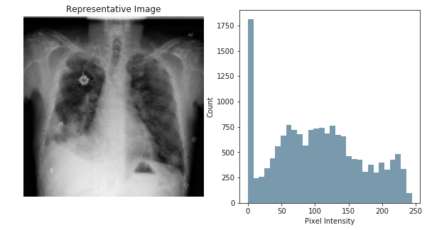

```python
plotHistogram(x[1])
```

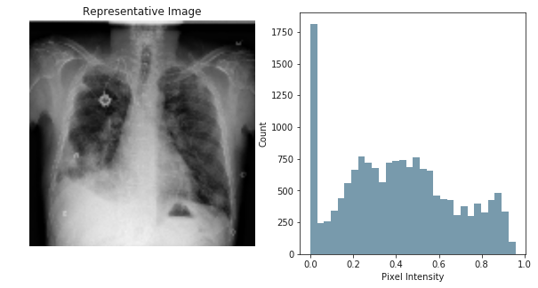

```python
x=np.array(x)
x=x/255.0
plotHistogram(x[1])
```

Describe distribution of class labels

```
{1: 'Consolidation', 2: 'Infiltration', 3: 'Pneumothorax', 4: 'Effusion', 5: 'Nodule Mass', 6: 'Atelectasis', 7: 'Other Rare Classes'}
```

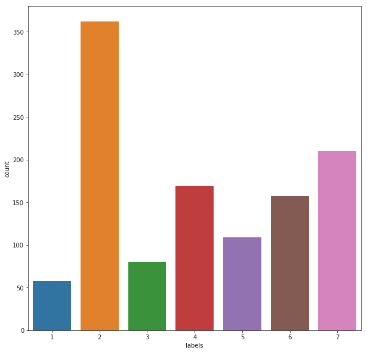

```python
lab = df['labels']
dist = lab.value_counts()
sns.countplot(lab)
print(dict_characters)
```

use a CNN to predict each ailment based off of the X-Ray image.

```python
# Encode labels to hot vectors (ex : 2 -> [0,0,1,0,0,0,0,0,0,0])
Y_trainHot = to_categorical(Y_train, num_classes = 8)
Y_testHot = to_categorical(Y_test, num_classes = 8)
```

In order to avoid having a biased model because of skewed class sizes, I will modify the class_weights parameter in order to give more weight to the rare classes. In this case the class_weights parameter will eventually be passed to the model.fit function.

```python
from sklearn.utils import class_weight
class_weight = class_weight.compute_class_weight('balanced', np.unique(y), y)
print(class_weight)
```

```
[2.82019704 0.45185478 2.04464286 0.96787828 1.50065531 1.04185623
 0.77891156]
```

Functions Learning Curves and Confusion Matrix

```python
from keras.callbacks import Callback, EarlyStopping, ReduceLROnPlateau, ModelCheckpoint

class MetricsCheckpoint(Callback):
    """Callback that saves metrics after each epoch"""
    def __init__(self, savepath):
        super(MetricsCheckpoint, self).__init__()
        self.savepath = savepath
        self.history = {}
    def on_epoch_end(self, epoch, logs=None):
        for k, v in logs.items():
            self.history.setdefault(k, []).append(v)
        np.save(self.savepath, self.history)

def plotKerasLearningCurve():
    plt.figure(figsize=(10,5))
    metrics = np.load('logs.npy')[()]
    filt = ['acc'] # try to add 'loss' to see the loss learning curve
    for k in filter(lambda x : np.any([kk in x for kk in filt]), metrics.keys()):
        l = np.array(metrics[k])
        plt.plot(l, c= 'r' if 'val' not in k else 'b', label='val' if 'val' in k else 'train')
        x = np.argmin(l) if 'loss' in k else np.argmax(l)
        y = l[x]
        plt.scatter(x,y, lw=0, alpha=0.25, s=100, c='r' if 'val' not in k else 'b')
        plt.text(x, y, '{} = {:.4f}'.format(x,y), size='15', color= 'r' if 'val' not in k else 'b')
    plt.legend(loc=4)
    plt.axis([0, None, None, None]);
    plt.grid()
    plt.xlabel('Number of epochs')

def plot_confusion_matrix(cm, classes,
                          normalize=False,
                          title='Confusion matrix',
                          cmap=plt.cm.Blues):
    """
    This function prints and plots the confusion matrix.
    Normalization can be applied by setting `normalize=True`.
    """
    plt.figure(figsize = (5,5))
    plt.imshow(cm, interpolation='nearest', cmap=cmap)
    plt.title(title)
    plt.colorbar()
    tick_marks = np.arange(len(classes))
    plt.xticks(tick_marks, classes, rotation=90)
    plt.yticks(tick_marks, classes)
    if normalize:
        cm = cm.astype('float') / cm.sum(axis=1)[:, np.newaxis]

    thresh = cm.max() / 2.
    for i, j in itertools.product(range(cm.shape[0]), range(cm.shape[1])):
        plt.text(j, i, cm[i, j],
                 horizontalalignment="center",
                 color="white" if cm[i, j] > thresh else "black")
    plt.tight_layout()
    plt.ylabel('True label')
    plt.xlabel('Predicted label')

def plot_learning_curve(history):
    plt.figure(figsize=(8,8))
    plt.subplot(1,2,1)
    plt.plot(history.history['acc'])
    plt.plot(history.history['val_acc'])
    plt.title('model accuracy')
    plt.ylabel('accuracy')
    plt.xlabel('epoch')
    plt.legend(['train', 'test'], loc='upper left')
    plt.savefig('./accuracy_curve.png')
    #plt.clf()
    # summarize history for loss
    plt.subplot(1,2,2)
    plt.plot(history.history['loss'])
    plt.plot(history.history['val_loss'])
    plt.title('model loss')
    plt.ylabel('loss')
    plt.xlabel('epoch')
    plt.legend(['train', 'test'], loc='upper left')
    plt.savefig('./loss_curve.png')
```

```python
X_train, X_test, Y_train, Y_test = train_test_split(x, y, test_size=0.2)
# Reduce Sample Size for DeBugging
X_train = X_train[0:4370]
Y_train = Y_train[0:4370]
X_test = X_test[0:1748]
Y_test = Y_test[0:1748]
```

```python
# Make Data 1D for compatability upsampling methods
X_trainShape = X_train.shape[1]*X_train.shape[2]*X_train.shape[3]
X_testShape = X_test.shape[1]*X_test.shape[2]*X_test.shape[3]
X_trainFlat = X_train.reshape(X_train.shape[0], X_trainShape)
X_testFlat = X_test.reshape(X_test.shape[0], X_testShape)
print("X_train Shape: ",X_train.shape)
print("X_test Shape: ",X_test.shape)
print("X_trainFlat Shape: ",X_trainFlat.shape)
print("X_testFlat Shape: ",X_testFlat.shape)
```

```
X_train Shape:  (916, 128, 128, 3)
X_test Shape:  (229, 128, 128, 3)
X_trainFlat Shape:  (916, 49152)
X_testFlat Shape:  (229, 49152)
```

```python
from imblearn.over_sampling import RandomOverSampler
ros = RandomOverSampler(ratio='auto')
X_trainRos, Y_trainRos = ros.fit_sample(X_trainFlat, Y_train)
X_testRos, Y_testRos = ros.fit_sample(X_testFlat, Y_test)

# Encode labels to hot vectors (ex : 2 -> [0,0,1,0,0,0,0,0,0,0])
Y_trainRosHot = to_categorical(Y_trainRos, num_classes = 8)
Y_testRosHot = to_categorical(Y_testRos, num_classes = 8)
print("X_train: ", X_train.shape)
print("X_trainFlat: ", X_trainFlat.shape)
print("X_trainRos Shape: ",X_trainRos.shape)
print("X_testRos Shape: ",X_testRos.shape)
print("Y_trainRosHot Shape: ",Y_trainRosHot.shape)
print("Y_testRosHot Shape: ",Y_testRosHot.shape)
```

```
X_train:  (916, 128, 128, 3)
X_trainFlat:  (916, 49152)
X_trainRos Shape:  (2051, 49152)
X_testRos Shape:  (483, 49152)
Y_trainRosHot Shape:  (2051, 8)
Y_testRosHot Shape:  (483, 8)
```

```python
for i in range(len(X_trainRos)):
    height, width, channels = 128,128,3
    X_trainRosReshaped = X_trainRos.reshape(len(X_trainRos),height,width,channels)
print("X_trainRos Shape: ",X_trainRos.shape)
print("X_trainRosReshaped Shape: ",X_trainRosReshaped.shape)

for i in range(len(X_testRos)):
    height, width, channels = 128,128,3
    X_testRosReshaped = X_testRos.reshape(len(X_testRos),height,width,channels)
print("X_testRos Shape: ",X_testRos.shape)
print("X_testRosReshaped Shape: ",X_testRosReshaped.shape)
```

```
X_trainRos Shape:  (2051, 49152)
X_trainRosReshaped Shape:  (2051, 128, 128, 3)
X_testRos Shape:  (483, 49152)
X_testRosReshaped Shape:  (483, 128, 128, 3)
```

```
{1: 'Consolidation', 2: 'Infiltration', 3: 'Pneumothorax', 4: 'Effusion', 5: 'Nodule Mass', 6: 'Atelectasis', 7: 'Other Rare Classes'}
```

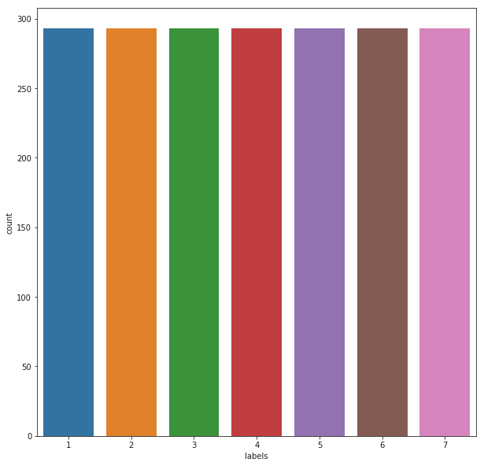

```python
dfRos = pd.DataFrame()
dfRos["labels"]=Y_trainRos
labRos = dfRos['labels']
distRos = lab.value_counts()
sns.countplot(labRos)
print(dict_characters)
```

```python
from sklearn.utils import class_weight
class_weight = class_weight.compute_class_weight('balanced', np.unique(y), y)
print("Old Class Weights: ",class_weight)
from sklearn.utils import class_weight
class_weight = class_weight.compute_class_weight('balanced', np.unique(Y_trainRos), Y_trainRos)
print("New Class Weights: ",class_weight)
```

```
Old Class Weights:  [2.82019704 0.45185478 2.04464286 0.96787828 1.50065531 1.04185623
 0.77891156]
New Class Weights:  [1. 1. 1. 1. 1. 1. 1.]
```